# Effects of Used Cars Maximum Power,Purchase Year, and Transmission on Their Selling Prices

## by Gbenga Olurankinse

## Investigation Overview

In this investigation, I wanted to look at the effects of Maximum Power, Owner, Purchase Year and Transmission of used cars on their selling prices.

## Dataset Overview

The data consisted of used cars selling price, maximum power, owner, amongst others, with 7906 attributes. some not required columns were dropped for the course of this analysis.

## Distribution of Used Car Selling Prices

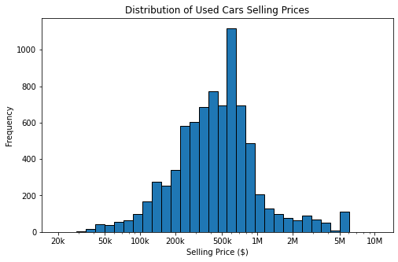

## Selling Prices vs Maximum Engine of the used cars

Plotting the selling price on a log scale against the standard scale of the maximum power of the used cars, produces a strong positive relationship. As the maximum power increases, the selling price increases.

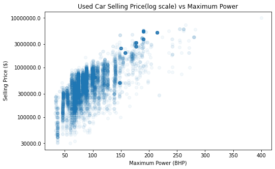

## Selling Price of Used Cars vs Purchase Year

plotting the selling price on a log scale against the year the used cars were purchase shows a positive relationship. As the year becoming recent from 1994-1999 to 2020, the cost of the used cars increases. no significant increment between year 2010-2019 and 2020 due to limited datapoints of used cars in 2020.

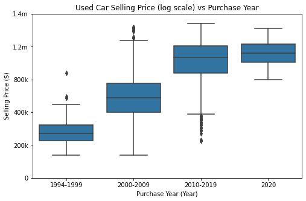

## What is the relationship between Selling Price of Used Cars vs Transmission

plotting selling price against transmission of the used cars denote that Automatic used cars are more expensive than manual used cars.

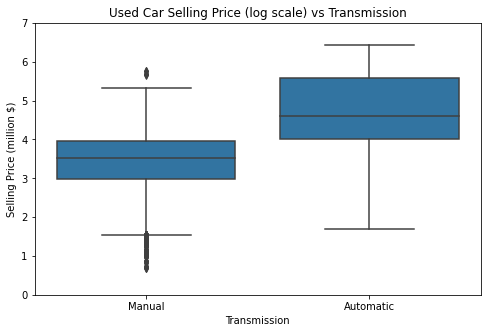

## Selling Price of Used Cars and Maximum Power Across Purchase Year

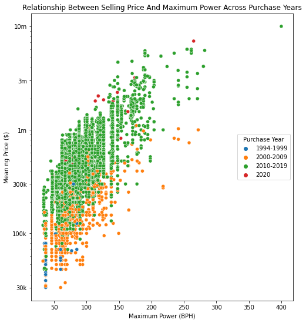

## Selling Price of Used Cars and Purchase Year Across Transmission

Looking at the plot of effect of used cars transmission on selling price and purchase year, The average selling price of automatic cars across the year is always higher than the average selling price of manual used cars.

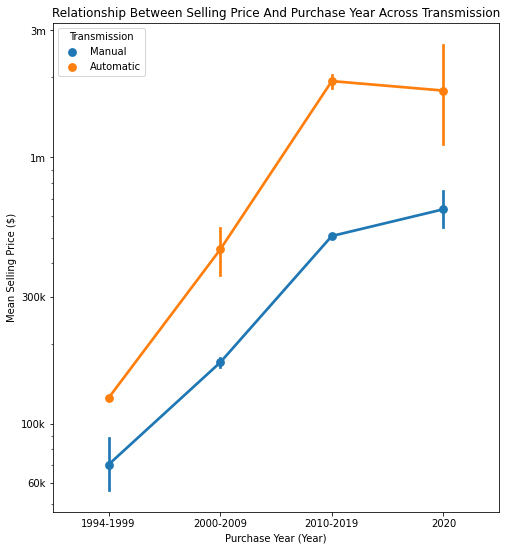